# Grocery Transaction Rules

BryanEng

November 30, 2018

The Groceries data set contains 1 month (30 days) of real-world point-of-sale transaction data from a typical local grocery outlet. The data set contains 9835 transactions with items that are aggregated to 169 categories, stored in sparse format. The dataset is part of the “arules” package and can be loaded by calling data(Groceries).

## Tasks

In this assignment, you will gain practical experience with mining frequent itemsets and association rules. Solve the tasks using R (package “arules”) and answer the questions.

```r
library(arules)
data(Groceries)
```

## Task 1

Plot a histogram of the number of items (number of categories) per transaction. What do you observe? How can you explain this observation?

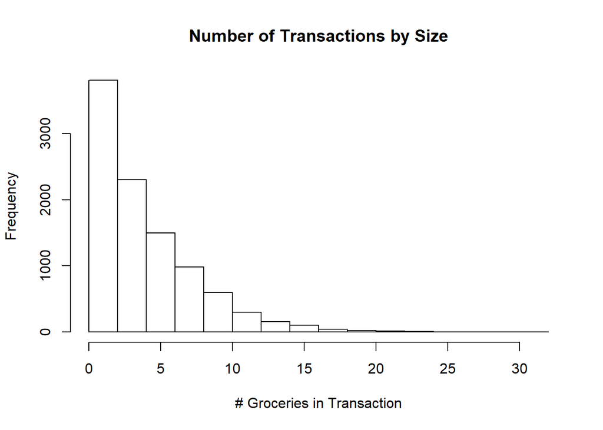

```r
hist(size(Groceries), main = "Number of Transactions by Size", xlab = "# Groceries in Transaction")
```

Most people only buy a small amount of items from a grocery store. Usually they only the few items they need at that moment, rather than buying all their groceries at once.

## Task 2

How many frequent itemsets, closed frequent itemsets, and maximal frequent itemsets do you obtain with minimum support = 0.001? How many with minimum support = 0.01?

```r
freq_items1 = eclat(Groceries, parameter = list(supp = 0.001))
```

```
## Eclat
##
## parameter specification:
##  tidLists support minlen maxlen            target   ext
##     FALSE   0.001      1     10 frequent itemsets FALSE
##
## algorithmic control:
##  sparse sort verbose
##       7   -2    TRUE
##
## Absolute minimum support count: 9
##
## create itemset ...
## set transactions ...[169 item(s), 9835 transaction(s)] done [0.00s].
## sorting and recoding items ... [157 item(s)] done [0.00s].
## creating sparse bit matrix ... [157 row(s), 9835 column(s)] done [0.00s].
## writing  ... [13492 set(s)] done [0.04s].
## Creating S4 object  ... done [0.00s].
```

```r
length(freq_items1)
```

```
## [1] 13492
```

```r
closed1 = is.closed(freq_items1)
length(closed1[closed1 == TRUE])
```

```
## [1] 13464
```

```r
max1 = is.maximal(freq_items1)
length(max1[max1 == TRUE])
```

```
## [1] 7794
```

```r
freq_items2 = eclat(Groceries, parameter = list(supp = 0.01))
```

```
## Eclat
##
## parameter specification:
##  tidLists support minlen maxlen            target   ext
##     FALSE    0.01      1     10 frequent itemsets FALSE
##
## algorithmic control:
##  sparse sort verbose
##       7   -2    TRUE
##
## Absolute minimum support count: 98
##
## create itemset ...
## set transactions ...[169 item(s), 9835 transaction(s)] done [0.00s].
## sorting and recoding items ... [88 item(s)] done [0.00s].
## creating sparse bit matrix ... [88 row(s), 9835 column(s)] done [0.00s].
## writing  ... [333 set(s)] done [0.01s].
## Creating S4 object  ... done [0.00s].
```

```r
length(freq_items2)
```

```
## [1] 333
```

```r
closed2 = is.closed(freq_items2)
length(closed2[closed2 == TRUE])
```

```
## [1] 333
```

```r
max2 = is.maximal(freq_items2)
length(max2[max2 == TRUE])
```

```
## [1] 243
```

For support of 0.001, there are a total of 13492 frequent itemsets, 13464 closed itemsets, and 7794 maximal itemsets. For support of 0.01, there are a total of 333 frequent itemsets, 333 closed itemsets, and 243 maximal itemsets.

## Task 3

What are the 10 itemsets with the highest support, and what is their support?

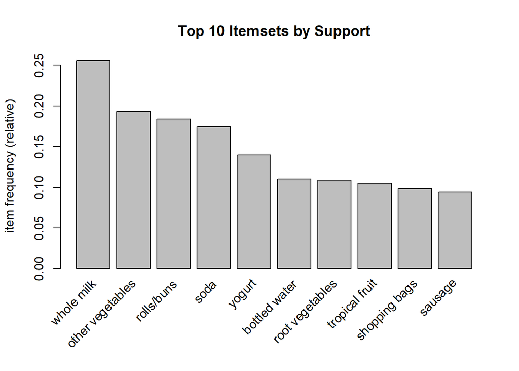

```r
itemFrequencyPlot(Groceries, topN = 10, main="Top 10 Itemsets by Support")
```

```r
head(sort(itemFrequency(Groceries), decreasing = TRUE), n = 10)
```

```
##       whole milk other vegetables       rolls/buns             soda
##       0.25551601       0.19349263       0.18393493       0.17437722
##           yogurt    bottled water  root vegetables   tropical fruit
##       0.13950178       0.11052364       0.10899847       0.10493137
##    shopping bags          sausage
##       0.09852567       0.09395018
```

## Task 4

How do you explain the relatively small number of frequent itemsets for the already low minimum support of 0.01? How do you explain the observation that the numbers of frequent itemsets, closed frequent itemsets, and maximal frequent itemsets are so similar?

The majority of itemsets have a very small minimum support value because they don’t occur very frequently. Most people don’t tend to purchase the same types of products if they plan to buy items like candy, international goods, etc. That is why setting minimum support to 0.01 removes many of the itemsets. The most frequently occuring itemsets most likely are essential items that almost all shoppers buy at the grocery store. This includes staples like milk, bread, vegetables, etc. This would explain why the frequent itemsets, closed itemsets, and maximal itemsets are similar in size. While people can buy many different combinations of groceries, if they are only going to buy staple items then they are most likely to purchase the same kind of items.

## Task 5

At minimum support = 0.01, how many association rules do you obtain with minimum confidence = 0.9? How far do you need to lower the minimum confidence to obtain more than 10 rules?

```r
rules = apriori(Groceries, parameter = list(supp = 0.01, conf = 0.9))
```

```
## Apriori
##
## Parameter specification:
##  confidence minval smax arem  aval originalSupport maxtime support minlen
##         0.9    0.1    1 none FALSE            TRUE       5    0.01      1
##  maxlen target   ext
##      10  rules FALSE
##
## Algorithmic control:
##  filter tree heap memopt load sort verbose
##     0.1 TRUE TRUE  FALSE TRUE    2    TRUE
##
## Absolute minimum support count: 98
##
## set item appearances ...[0 item(s)] done [0.00s].
## set transactions ...[169 item(s), 9835 transaction(s)] done [0.00s].
## sorting and recoding items ... [88 item(s)] done [0.00s].
## creating transaction tree ... done [0.00s].
## checking subsets of size 1 2 3 4 done [0.00s].
## writing ... [0 rule(s)] done [0.00s].
## creating S4 object  ... done [0.00s].
```

```r
summary(rules)
```

```
## set of 0 rules
```

With minimum support of 0.01 and confidence of 0.9, no rules are generated.

```r
rules = apriori(Groceries, parameter = list(supp = 0.01, conf = 0.51))
```

```
## Apriori
##
## Parameter specification:
##  confidence minval smax arem  aval originalSupport maxtime support minlen
##        0.51    0.1    1 none FALSE            TRUE       5    0.01      1
##  maxlen target   ext
##      10  rules FALSE
##
## Algorithmic control:
##  filter tree heap memopt load sort verbose
##     0.1 TRUE TRUE  FALSE TRUE    2    TRUE
##
## Absolute minimum support count: 98
##
## set item appearances ...[0 item(s)] done [0.00s].
## set transactions ...[169 item(s), 9835 transaction(s)] done [0.00s].
## sorting and recoding items ... [88 item(s)] done [0.00s].
## creating transaction tree ... done [0.00s].
## checking subsets of size 1 2 3 4 done [0.00s].
## writing ... [12 rule(s)] done [0.00s].
## creating S4 object  ... done [0.00s].
```

```r
summary(rules)
```

```
## set of 12 rules
##
## rule length distribution (lhs + rhs):sizes
##  3
## 12
##
##    Min. 1st Qu.  Median    Mean 3rd Qu.    Max.
##       3       3       3       3       3       3
##
## summary of quality measures:
##     support          confidence          lift           count
##  Min.   :0.01007   Min.   :0.5129   Min.   :2.007   Min.   : 99.0
##  1st Qu.:0.01134   1st Qu.:0.5216   1st Qu.:2.042   1st Qu.:111.5
##  Median :0.01230   Median :0.5578   Median :2.183   Median :121.0
##  Mean   :0.01313   Mean   :0.5506   Mean   :2.277   Mean   :129.2
##  3rd Qu.:0.01378   3rd Qu.:0.5758   3rd Qu.:2.253   3rd Qu.:135.5
##  Max.   :0.02227   Max.   :0.5862   Max.   :3.030   Max.   :219.0
##
## mining info:
##       data ntransactions support confidence
##  Groceries          9835    0.01       0.51
```

## Task 6

For minimum support = 0.01 and minimum confidence = 0.5, print only the rules that have “whole milk” in their right hand side.

```r
rules = apriori(Groceries, parameter = list(supp = 0.01, conf = 0.5))
```

```
## Apriori
##
## Parameter specification:
##  confidence minval smax arem  aval originalSupport maxtime support minlen
##         0.5    0.1    1 none FALSE            TRUE       5    0.01      1
##  maxlen target   ext
##      10  rules FALSE
##
## Algorithmic control:
##  filter tree heap memopt load sort verbose
##     0.1 TRUE TRUE  FALSE TRUE    2    TRUE
##
## Absolute minimum support count: 98
##
## set item appearances ...[0 item(s)] done [0.00s].
## set transactions ...[169 item(s), 9835 transaction(s)] done [0.00s].
## sorting and recoding items ... [88 item(s)] done [0.00s].
## creating transaction tree ... done [0.00s].
## checking subsets of size 1 2 3 4 done [0.00s].
## writing ... [15 rule(s)] done [0.00s].
## creating S4 object  ... done [0.00s].
```

```r
milk_rules = subset(rules, subset = rhs %pin% "whole milk")
inspect(milk_rules)
```

```
##      lhs                     rhs             support confidence     lift count
## [1]  {curd,
##       yogurt}             => {whole milk} 0.01006609  0.5823529 2.279125    99
## [2]  {other vegetables,
##       butter}             => {whole milk} 0.01148958  0.5736041 2.244885   113
## [3]  {other vegetables,
##       domestic eggs}      => {whole milk} 0.01230300  0.5525114 2.162336   121
## [4]  {yogurt,
##       whipped/sour cream} => {whole milk} 0.01087951  0.5245098 2.052747   107
## [5]  {other vegetables,
##       whipped/sour cream} => {whole milk} 0.01464159  0.5070423 1.984385   144
## [6]  {pip fruit,
##       other vegetables}   => {whole milk} 0.01352313  0.5175097 2.025351   133
## [7]  {tropical fruit,
##       root vegetables}    => {whole milk} 0.01199797  0.5700483 2.230969   118
## [8]  {tropical fruit,
##       yogurt}             => {whole milk} 0.01514997  0.5173611 2.024770   149
## [9]  {root vegetables,
##       yogurt}             => {whole milk} 0.01453991  0.5629921 2.203354   143
## [10] {root vegetables,
##       rolls/buns}         => {whole milk} 0.01270971  0.5230126 2.046888   125
## [11] {other vegetables,
##       yogurt}             => {whole milk} 0.02226741  0.5128806 2.007235   219
```

## Task 7

Among the rules produced in task 6, which ones have the highest lift? How interesting are they?

The rules with the highest lift are curd, yogurt => milk with lift of 2.28, other vegetables, butter => milk with lift 2.24, and tropical fruit, root vegetables => milk with lift of 2.23. These results are interesting because a lift that is much greater than 1 indicates a strong association in the rule.